# NARPS Design Simulations

This notebook contains simulations to examine different options for modeling the design of the NARPS study.

The goal of the study is to present subjects with one of two different gamble distributions:

- indifference distribution (Tom et al., 2007): The range of gains ($10-$40 by 2) is twice the range of losses ($5-$20), such that the median gamble falls roughly at the average subject’s point of indifference (given an average loss aversion coefficient of ~2)
- equal distribution (de Martino et al., 2010): The range of gains is exactly the range of losses, such that the majority of gambles will fall below the subject’s point of indifference and thus be rejected.

The statistical model for the first level responses (after Tom et al.) will be:

$$y = \beta_0*intercept + \beta_1*gain + \beta_2*loss$$
where the intercept can be interpreted as the overall tendency towards gambling.

The goal of these simulations is to determine how to arrange the gambles and the model such that a subject with equal utility and risk preference would exhibit equal model parameters across the two gamble distributions.

First we set up the gamble structures. For this example we assume expected value computed via prospect theory with a loss aversion lambda of 2 and linear value functions for gains and losses. We start using identical gain distributions across conditions.

```r
msize=16
pt_lambda=2
gains_indiff=seq(from=10,length.out=16,by=2)
loss_indiff=seq(from=5,length.out=16,by=1)

gains_equal=gains_indiff
loss_equal=gains_equal

df=data.frame(gain_indiff=kronecker(array(1,dim=16),gains_indiff),
                  loss_indiff=kronecker(loss_indiff,array(1,dim=16)),
              gain_equal=kronecker(array(1,dim=16),gains_equal),
                  loss_equal=kronecker(loss_equal,array(1,dim=16))
              )
```

Now let’s simulate the subject’s brain responses to these gambles. For now we just assume that the brain response is a function of prospect theory EV, and we fit a linear regression model to each dataset to assess parameter recovery. First generate a function to do this.

```r
library(QuantPsyc) # for lm.beta
domodel <- function(df,noise_sd=1,pt_lambda=2,stdize=TRUE) {
  df$ev_indiff=df$gain_indiff - df$loss_indiff*pt_lambda
  df$ev_equal=df$gain_equal - df$loss_equal*pt_lambda
  df$resp_indiff=df$ev_indiff+rnorm(dim(df)[1])*noise_sd
  df$resp_equal=df$ev_equal+rnorm(dim(df)[1])*noise_sd
  lm.indiff=lm(resp_indiff~gain_indiff + loss_indiff, data=df)
  lm.equal=lm(resp_equal~gain_equal + loss_equal, data=df)
  la_equal=(-1*lm.equal$coefficients[3])/lm.equal$coefficients[2]
  la_indiff=(-1*lm.indiff$coefficients[3])/lm.indiff$coefficients[2]
  if (stdize){
     return(c(lm.beta(lm.equal),
           lm.beta(lm.indiff),
           la_equal,la_indiff))
  } else {
      return(c(lm.equal$coefficients[2],lm.equal$coefficients[3],
           lm.indiff$coefficients[2],lm.indiff$coefficients[3],
           la_equal,la_indiff))

  }
}
```

Now let’s loop through a range of plausible lambda values and see how well each model can recover the parameters. First do it using unstandardized regression parameters.

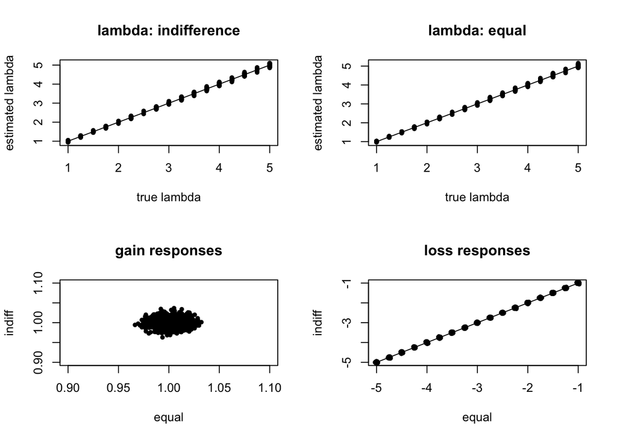

```r
lamvals=seq(1,5,by=0.25)
nruns=100
temp=1.5
simresults=c()
for (lam in lamvals){
  for (i in 1:nruns){
    tmp=domodel(df,temp,lam,stdize=FALSE)
    simresults=cbind(simresults,c(lam,tmp))
  }
}

sim.df=data.frame(t(simresults))
names(sim.df)=c('lam',"gain_equal","loss_equal","gain_indiff","loss_indiff",
  "la_equal","la_indiff")

lam_ests=aggregate(la_equal~lam, data=sim.df, FUN=function(x) c(mean=mean(x)))
lam_ests$la_indiff=aggregate(la_indiff~lam, data=sim.df, FUN=function(x) c(mean=mean(x)))$la_indiff
par(mfrow=c(2,2))
plot(sim.df$lam,sim.df$la_indiff,pch=20,main='lambda: indifference',xlab='true lambda',ylab='estimated lambda')
lines(c(1,5),c(1,5))
plot(sim.df$lam,sim.df$la_equal,pch=20,main='lambda: equal',xlab='true lambda',ylab='estimated lambda')
lines(c(1,5),c(1,5))

plot(sim.df$gain_equal,sim.df$gain_indiff,pch=20,main='gain responses',xlab='equal',ylab='indiff',xlim=c(0.9,1.1),ylim=c(0.9,1.1))
#lines(c(0,1),c(0,1))

plot(sim.df$loss_equal,sim.df$loss_indiff,pch=20,main='loss responses',xlab='equal',ylab='indiff',xlim=c(-5,-1),ylim=c(-5,-1))
lines(c(-5,-1),c(-5,-1))
```

Compare slopes of loss responses between models

```r
loss_lm=lm(loss_equal~loss_indiff,data=sim.df)
print(loss_lm)
```

```
##
## Call:
## lm(formula = loss_equal ~ loss_indiff, data = sim.df)
##
## Coefficients:
## (Intercept)  loss_indiff
##   -0.003605     0.998998
```

We see that the parameters match well when using unstandardized regression coefficients: * the estimated loss aversion coefficients and loss parameter closely align with the actual * there is no systematic variability in gain parameters * the slope of the loss estimates for the equal model matches that for the indifference model very closely

Now do the same using standardized regression parameters.

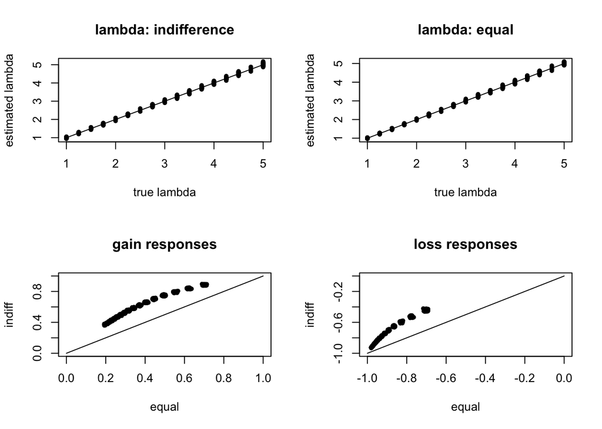

```r
simresults=c()
for (lam in lamvals){
  for (i in 1:nruns){
    tmp=domodel(df,temp,lam,stdize=TRUE)
    simresults=cbind(simresults,c(lam,tmp))
  }
}

sim.df.std=data.frame(t(simresults))
names(sim.df.std)=c('lam',"gain_equal","loss_equal","gain_indiff","loss_indiff",
  "la_equal","la_indiff")

lam_ests=aggregate(la_equal~lam, data=sim.df.std, FUN=function(x) c(mean=mean(x)))
lam_ests$la_indiff=aggregate(la_indiff~lam, data=sim.df.std, FUN=function(x) c(mean=mean(x)))$la_indiff
par(mfrow=c(2,2))
plot(sim.df.std$lam,sim.df.std$la_indiff,pch=20,main='lambda: indifference',xlab='true lambda',ylab='estimated lambda')
lines(c(1,5),c(1,5))
plot(sim.df.std$lam,sim.df.std$la_equal,pch=20,main='lambda: equal',xlab='true lambda',ylab='estimated lambda')
lines(c(1,5),c(1,5))

plot(sim.df.std$gain_equal,sim.df.std$gain_indiff,pch=20,main='gain responses',xlab='equal',ylab='indiff',xlim=c(0,1),ylim=c(0,1))
lines(c(0,1),c(0,1))

plot(sim.df.std$loss_equal,sim.df.std$loss_indiff,pch=20,main='loss responses',xlab='equal',ylab='indiff',xlim=c(-1,0),ylim=c(-1,0))
lines(c(-1,0),c(-1,0))
```

```r
loss_lm=lm(loss_equal~loss_indiff,data=sim.df.std)
print(loss_lm)
```

```
##
## Call:
## lm(formula = loss_equal ~ loss_indiff, data = sim.df.std)
##
## Coefficients:
## (Intercept)  loss_indiff
##     -0.5023       0.5301
```

This shows us that the analysis performs incorrectly when using standardized regression parameters: * Loss responses are not consistent between the two gamble distributions * Gain responses now show systematic variability

However, loss aversion coefficients are still properly estimated.